# BayesGP: COVID-19 Example

```r
library(BayesGP)
```

# COVID-19 Example

## Data and Model

We will illustrate the use of BayesGP using the `covid_canada` dataset, which contains the daily death count of COVID-19 in Canada.

```r
head(covid_canada)
```

```
#>         Date new_deaths        t weekdays1 weekdays2 weekdays3 weekdays4
#> 1 2020-03-01          0 591.0323        -1        -1        -1        -1
#> 2 2020-03-02          0 591.0645         1         0         0         0
#> 3 2020-03-03          0 591.0968         0         1         0         0
#> 4 2020-03-04          0 591.1290         0         0         1         0
#> 5 2020-03-05          0 591.1613         0         0         0         1
#> 6 2020-03-06          0 591.1935         0         0         0         0
#>   weekdays5 weekdays6 index
#> 1        -1        -1     1
#> 2         0         0     2
#> 3         0         0     3
#> 4         0         0     4
#> 5         0         0     5
#> 6         1         0     6
```

For simplicity, let’s consider the following model:
$$Y_i|\lambda_i \sim
\text{Poisson}(\lambda_i)$$
$$\log(\lambda_i) =
\mathbf{x}_i^T\boldsymbol{\beta} + f(t_i)$$
where $\mathbf{x}_i$ denotes the fixed effect of weekdays, and $f$ is an unknown function to be inferred.

To make inference of the unknown function $f$, we use the $\text{IWP}_3(\sigma)$ model:
$$\frac{\partial^p{f}(t)}{\partial t^p} = \sigma
\xi(t),$$
with the boundary (initial) conditions that $\frac{\partial^q{f}(0)}{\partial t^q} = 0$ for all $0\leq q <p$. Here $\xi(t)$ is the standard Gaussian white noise process, or can be viewed as the distributional derivative of the standard Brownian motion.

## Inference

To fit the above model using the BayesGP package, we simply do the following:

```r
fit_result <- model_fit(new_deaths ~ weekdays1 + weekdays2 + weekdays3 + weekdays4 + weekdays5 + weekdays6 +
                          f(smoothing_var = t, model = "IWP", order = 3, k = 100, sd.prior = list(prior = "exp", param = list(u = 0.02, alpha = 0.5), h = 1)),
                        data = covid_canada, method = "aghq", family = "Poisson")
```

We can take a look at the posterior summary of this model:

```r
summary(fit_result)
```

```
#> Here are some posterior/prior summaries for the parameters:
#>        name median q0.025 q0.975       prior prior:P1 prior:P2
#> 1 intercept  3.663  3.585  3.737      Normal     0.00    1e+03
#> 2 weekdays1  0.093  0.069  0.117      Normal     0.00    1e+03
#> 3 weekdays2  0.080  0.055  0.104      Normal     0.00    1e+03
#> 4 weekdays3  0.127  0.102  0.151      Normal     0.00    1e+03
#> 5 weekdays4  0.125  0.102  0.149      Normal     0.00    1e+03
#> 6 weekdays5  0.049  0.025  0.074      Normal     0.00    1e+03
#> 7 weekdays6 -0.152 -0.179 -0.125      Normal     0.00    1e+03
#> 8   t (PSD)  1.081  0.870  1.339 Exponential     0.02    5e-01
#> For Normal prior, P1 is its mean and P2 is its variance.
#> For Exponential prior, prior is specified as P(theta > P1) = P2.
```

We can also see the inferred function $f$:

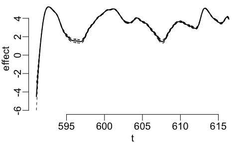

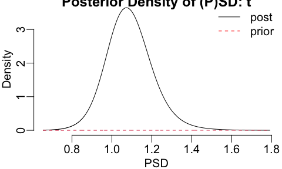

```r
plot(fit_result)
```

We can use the `predict` function to obtain the posterior summary of $f$ or its derivative at `new_data`:

For the function $f$:

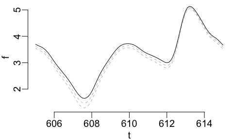

```r
predict_f <- predict(fit_result, variable = "t", newdata = data.frame(t = seq(from = 605, to = 615, by = 0.1)))
matplot(x = predict_f[,1], y = predict_f[,2:4], type = 'l', ylab = "f", xlab = "t", col = c("grey", "grey", "black"), lty = c("dashed", "dashed", "solid"))
```

For the first derivative:

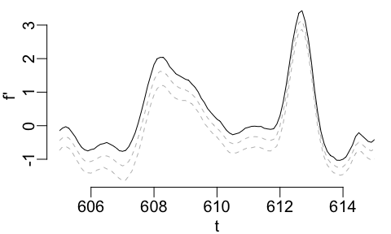

```r
predict_f1st <- predict(fit_result, variable = "t", newdata = data.frame(t = seq(from = 605, to = 615, by = 0.1)), deriv = 1)
matplot(x = predict_f1st[,1], y = predict_f1st[,2:4], type = 'l', ylab = "f'", xlab = "t", col = c("grey", "grey", "black"), lty = c("dashed", "dashed", "solid"))
```

For the second derivative:

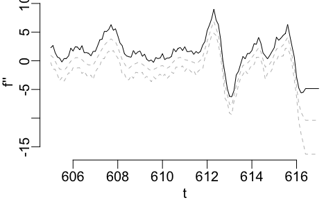

```r
predict_f2nd <- predict(fit_result, variable = "t", newdata = data.frame(t = seq(from = 605, to = 617, by = 0.1)), deriv = 2)
matplot(x = predict_f2nd[,1], y = predict_f2nd[,2:4], type = 'l', ylab = "f''", xlab = "t", col = c("grey", "grey", "black"), lty = c("dashed", "dashed", "solid"))
```

```r
par(oldpar)
```